# FFT lab: reproducing analytical FT with Python

Use the FFT as a **numerical approximation** of the continuous FT. $$ X(f) = \int_{-\infty}^{\infty} x(t)\, e^{-i2\pi f t}\, dt $$ and its inverse $$ x(t) = \int_{-\infty}^{\infty} X(f)\, e^{i2\pi f t}\, df $$ Main recipe:

$$ t_n = nT,\qquad f_s=\frac{1}{T},\qquad X(f_k)\approx T\,\mathrm{FFT}\{x[n]\} $$ with corresponding frequencies

$$ f_k = \mathrm{fftfreq}(N,T). $$

```python
import numpy as np
import matplotlib.pyplot as plt
print(np.fft.fftfreq(2))
print(np.fft.fftfreq(4))
print(np.fft.fftfreq(8))
print(np.fft.fftfreq(8, 0.1))
```

```
[ 0.  -0.5]
[ 0.    0.25 -0.5  -0.25]
[ 0.     0.125  0.25   0.375 -0.5   -0.375 -0.25  -0.125]
[ 0.    1.25  2.5   3.75 -5.   -3.75 -2.5  -1.25]
```

**BEWARE!** The requency axis is not centered, i.e.,

instead of the structure: negative frequencies, 0, positive frequencies

we have the structure: 0, positive frequencies, negative frequencies

More precisely, the first N/2 elements ([:N//2]) of the FT correspond to amplitudes at zero and positive frequencies while the rest ([N//2:]) to negative frequencies.

```python
np.fft.fftshift(np.fft.fftfreq(8, 0.1))  # center the frequencies
```

```
array([-5.  , -3.75, -2.5 , -1.25,  0.  ,  1.25,  2.5 ,  3.75])
```

**Practical rules:**

1. choose $f_s$ high enough,
2. choose $N$ (window size) large enough,
3. choose $N$ to be integer power of two, e.g., $2^8$
4. build the frequency axis explicitly,
5. scale by $T$,
6. use `fftshift` when comparing with centered theoretical plots,
7. use long windows or edge decay for non-periodic signals,
8. zero-pad only for smoother display.

## 1. Minimal template

Use this every time:

$$ X(f_k)\approx T_s\sum_{n=0}^{N-1} x(t_n)e^{-i2\pi f_k t_n}. $$

So in code we use `Ts*np.fft.fft(x)`.

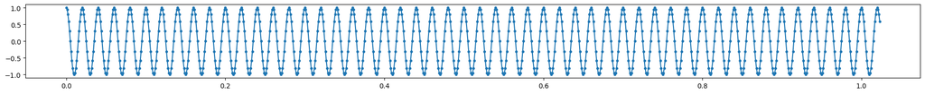

```python
# Sampling grid
fs = 1000.0
T = 1 / fs
N = 1024
t = np.arange(N) * T

# Example signal
f0 = 50.0
x = np.cos(2 * np.pi * f0 * t)
plt.figure(figsize=(24, 2))  # wide and short
plt.plot(t, x, '.-')
```

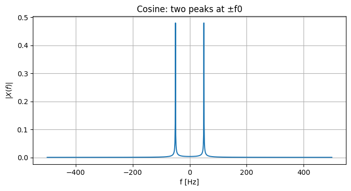

```python
# FFT scaled to approximate the continuous FT
X = T * np.fft.fft(x)
f = np.fft.fftfreq(N, T)

# Centered version for comparison with theoretical plots
Xc = np.fft.fftshift(X)
fc = np.fft.fftshift(f)

plt.figure(figsize=(8, 3.8))
plt.plot(fc, np.abs(Xc))
plt.xlabel("f [Hz]")
plt.ylabel(r"$|X(f)|$")
plt.title("Cosine: two peaks at ±f0")
plt.grid(True)
plt.show()
```

## 2. Frequency grid and resolution

The FFT returns values only on discrete frequencies:

$$ \Delta f = \frac{f_s}{N}. $$

Larger (N) means denser frequency samples.

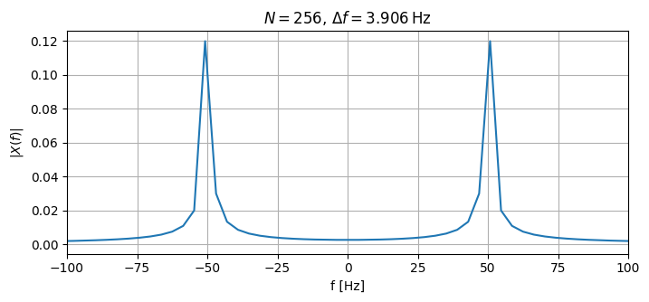

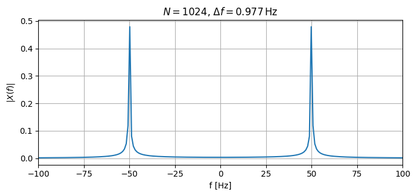

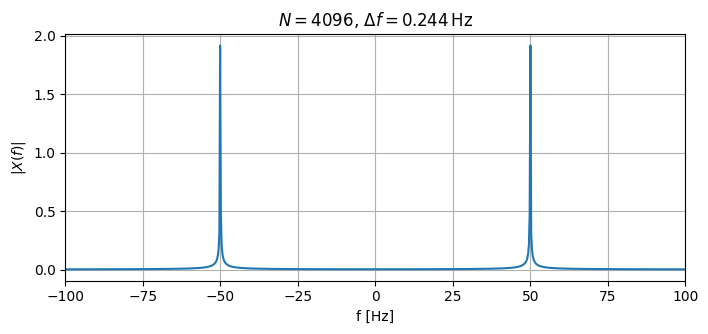

```python
for N in [256, 1024, 4096]:
    t = np.arange(N) / fs
    x = np.cos(2 * np.pi * f0 * t)
    X = T * np.fft.fft(x)
    f = np.fft.fftfreq(N, T)
    Xc = np.fft.fftshift(X)
    fc = np.fft.fftshift(f)

    plt.figure(figsize=(8, 3.2))
    plt.plot(fc, np.abs(Xc))
    plt.xlim(-100, 100)
    plt.xlabel("f [Hz]")
    plt.ylabel(r"$|X(f)|$")
    plt.title(fr"$N={N}$, $\Delta f = {fs/N:.3f}\,\mathrm{{Hz}}$")
    plt.grid(True)
    plt.show()
```

## 3. Window fit: good vs bad case

To make the FFT resemble the expected transform cleanly, it helps if the sampled signal fits the window well.

Example:

- good fit: integer number of periods in the window,
- bad fit: non-integer number of periods.

This is not a theory point; it is a **finite-window implementation issue**.

[figure not shown]

[figure not shown]

```python
T = 1.0
N = int(fs * T)
t = np.arange(N) / fs

signals = [
    (50.0, "good fit: 50 Hz in 1 s"),
    (50.5, "bad fit: 50.5 Hz in 1 s"),
]

for f0, title in signals:
    x = np.cos(2 * np.pi * f0 * t)
    X = T * np.fft.fft(x)
    f = np.fft.fftfreq(N, T)
    Xc = np.fft.fftshift(X)
    fc = np.fft.fftshift(f)

    plt.figure(figsize=(8, 3.2))
    plt.plot(fc, np.abs(Xc))
    plt.xlim(-80, 80)
    plt.xlabel("f [Hz]")
    plt.ylabel(r"$|X(f)|$")
    plt.title(title)
    plt.grid(True)
    plt.show()
```

## 4. Non-periodic functions: use a long enough window

Analytical transforms often assume infinite support, but the FFT only sees a finite interval.

Recipe: choose the window so that the function is already small near both ends.

Example:

$$ x(t)=e^{-a t^2}. $$

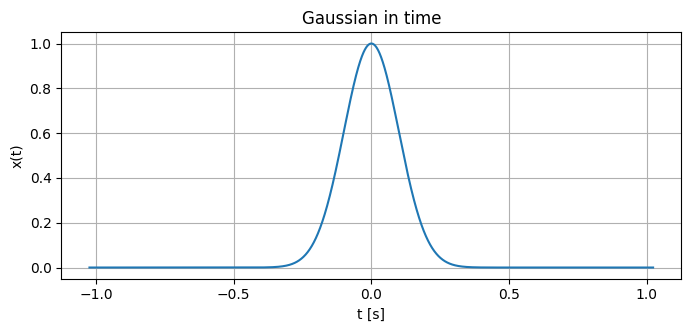

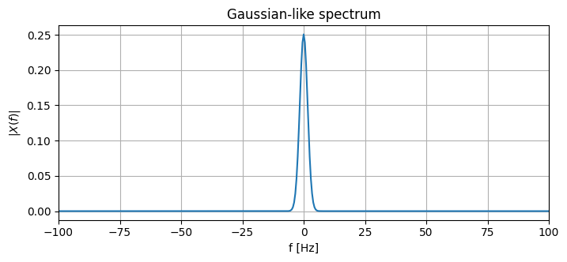

```python
fs = 2000.0
T = 1 / fs
N = 4096
t = (np.arange(N) - N//2) * T   # centered time grid

a = 50.0
x = np.exp(-a * t**2)

X = T * np.fft.fft(x)
f = np.fft.fftfreq(N, T)
Xc = np.fft.fftshift(X)
fc = np.fft.fftshift(f)

plt.figure(figsize=(8, 3.2))
plt.plot(t, x)
plt.xlabel("t [s]")
plt.ylabel("x(t)")
plt.title("Gaussian in time")
plt.grid(True)
plt.show()

plt.figure(figsize=(8, 3.2))
plt.plot(fc, np.abs(Xc))
plt.xlim(-100, 100)
plt.xlabel("f [Hz]")
plt.ylabel(r"$|X(f)|$")
plt.title("Gaussian-like spectrum")
plt.grid(True)
plt.show()
```

## Example:Rectangular pulse $\to$ sinc-shaped spectrum

A compact numerical demonstration of a standard transform pair.

$$ x(t)=\mathrm{rect}\!\left(\frac{t}{T_0}\right). $$

Again: use a centered grid and scale by $T$.

[figure not shown]

[figure not shown]

```python
fs = 4000.0
T = 1 / fs
N = 4096
t = (np.arange(N) - N//2) * T

T0 = 0.04
x = (np.abs(t) <= T0/2).astype(float)

X = Ts * np.fft.fft(x)
f = np.fft.fftfreq(N, Ts)
Xc = np.fft.fftshift(X)
fc = np.fft.fftshift(f)

plt.figure(figsize=(8, 3.2))
plt.plot(t, x)
plt.xlim(-0.08, 0.08)
plt.xlabel("t [s]")
plt.ylabel("x(t)")
plt.title("Rectangular pulse")
plt.grid(True)
plt.show()

plt.figure(figsize=(8, 3.2))
plt.plot(fc, np.abs(Xc))
plt.xlim(-200, 200)
plt.xlabel("f [Hz]")
plt.ylabel(r"$|X(f)|$")
plt.title("Sinc-shaped magnitude")
plt.grid(True)
plt.show()
```